# The Arizona Electorate in 2026

Registration and Voting

Christopher Weber

Professor  
School of Government and Public Policy  
University of Arizona  
chrisweber@arizona.edu

October 20, 2026

## The Arizona Voter Project

The AVP provides **public-facing tools, data, and analysis** to understand the political, social, and cultural characteristics of the Arizona electorate, with public resources to **access, experiment with, and interact with** Arizona’s voter file.

Voter File Data

Regular builds

Data Warehouse

Processing

Public Data

Aggregated

Interpretation

Analysis

Visualization

Broader understanding

### Data warehouse

Builds of the voter file over time, election records, Census data, and public opinion — secured under privacy protocols.

### Public data

Voting data aggregated to the boundaries people actually argue about: **counties, legislative and congressional districts, ZIP codes**.

### Analysis

Tools and research that turn the data into answers about **who registers, who votes, and how**.

### Visualization

Maps, charts, and dashboards that make the results **understandable and easy to explore**.

# Registration

## The electoral landscape

Figures throughout come from the Arizona Voter Project voter-file build, August 7, 2026.

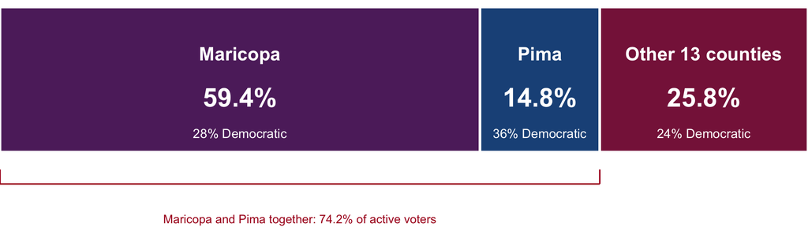

- **Maricopa alone is 59% of the state’s active registration** — 2,543,827 of 4,282,107 active registered voters.
- Add **Pima** (14.8%) and two counties hold roughly three quarters of the electorate.
- The remaining thirteen are small but **not uniform**: Mohave is 56% Republican.
- Apache is 50% Democratic, the most Democratic county in the state.

## Registration in Arizona Counties

[interactive chart not shown]

## Congressional District 6

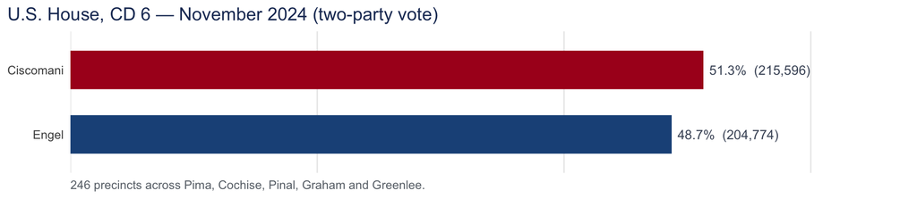

- A **historically competitive seat**. Giffords (AZ-08, Jan 2007 – Jan 2012, resigned); Barber (AZ-08 special Jun 2012; AZ-02 Jan 2013 – Jan 2015); McSally (AZ-02 Jan 2015 – Jan 2019); Kirkpatrick (AZ-02 Jan 2019 – Jan 2023) — became CD 6 for 2022, when Juan Ciscomani first won it.
- **2024 (two-party vote):** Ciscomani (R) 51.3% to Engel (D) 48.7% — a margin of **10,822 votes** on 420,370 cast.
- **2022:** Ciscomani (R) 50.73% to Engel (D) 49.23% — a margin of **5,232 votes** on 349,283 cast, the seat’s first election under the new boundaries. *AZ SoS 2022 General Election canvass.*
- Registration in CD 6 (Aug 2026 build): **29.7%** Democratic · **35.0%** neither party · **35.3%** Republican.

## Congressional District 6, over time

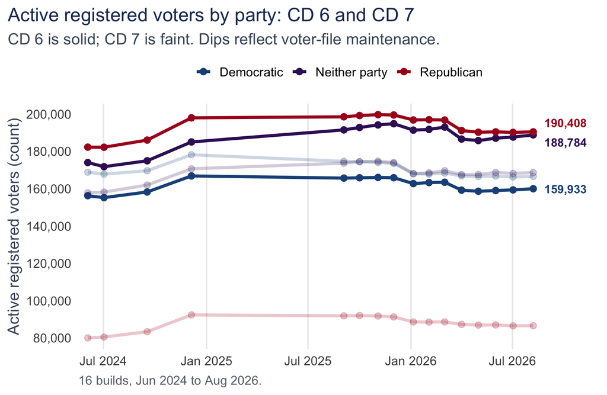

- **Total active:** 512,368 to 539,125 (+5.2%)
- **Democratic:** 156,193 to 159,933 (+2.4%)
- **Republican:** 182,214 to 190,408 (+4.5%)
- **Neither party:** 173,961 to 188,784 (+8.5%)
- *Fainter lines show CD 7, for comparison (the other Tucson district).*

## Registration, by County

| County | Active registered | Democratic | Neither party | Republican |
| --- | --- | --- | --- | --- |
| Maricopa | 2543827 | 27.90280156630148 | 37.44539231638001 | 34.65180611731851 |
| Pima | 634731 | 36.22321896992585 | 35.85960036613935 | 27.9171806639348 |
| Pinal | 285895 | 22.58696374543101 | 38.3116179016772 | 39.1014183528918 |
| Yavapai | 172156 | 18.03770998396803 | 30.75640697971608 | 51.2058830363159 |
| Mohave | 148254 | 12.08264195232506 | 31.7657533692177 | 56.15160467845724 |
| Yuma | 108559 | 26.4344734199836 | 41.38671137353882 | 32.17881520647758 |
| Coconino | 85928 | 38.48920026068336 | 35.15384973466158 | 26.35695000465506 |
| Cochise | 82702 | 22.66813378152886 | 37.51783511886048 | 39.81403109961065 |
| Navajo | 67455 | 29.49225409532281 | 29.47742939737603 | 41.03031650730117 |
| Apache | 50154 | 50.06380348526538 | 27.46341268891813 | 22.47278382581649 |

[output cut: 5 more lines]

- Statewide: **28.2%** Democratic · **36.5%** neither party · **35.3%** Republican
- Democratic across counties range **38 points** — 12.1% in Mohave to 50.1% in Apache
- Republican range is almost exactly as much: **38 points** — 18.5% in Santa Cruz to 56.2% in Mohave
- **Neither party is less variable:** range is only **14 points** — 27.5% in Apache to 41.4% in Yuma

**38 points against 14.** Each party’s share varies about 2.7 times as much across Arizona as the share registered with neither.

## Registration, by Congressional District

| District | Active registered | Democratic | Neither party | Republican |
| --- | --- | --- | --- | --- |
| CD 1 | 511,169 | 26.7 | 35.2 | 38.0 |
| CD 2 | 544,013 | 27.9 | 33.0 | 39.1 |
| CD 3 | 331,913 | 42.6 | 42.7 | 14.7 |
| CD 4 | 418,516 | 30.0 | 38.2 | 31.8 |
| CD 5 | 539,360 | 21.3 | 36.3 | 42.4 |
| CD 6 | 539,125 | 29.7 | 35.0 | 35.3 |
| CD 7 | 421,596 | 39.5 | 40.0 | 20.5 |
| CD 8 | 471,085 | 24.1 | 35.1 | 40.8 |
| CD 9 | 543,253 | 19.7 | 36.7 | 43.6 |

[interactive chart not shown]

- **Partisan differences are large:** Democratic registration range 23 points (19.7% in CD 9 to 42.6% in CD 3); Republican range 29 points (14.7% in CD 3 to 43.6% in CD 9).
- **Neither party is less variable:** its range is only 10 points (33.0% in CD 2 to 42.7% in CD 3) across the nine districts.

# How Arizonans vote

## Early voting is the norm

Statewide · 2026-08-07 build

### 74.1%

on the **Active Early Voting List** — a ballot arrives automatically for every election you remain enrolled.

### 85.5%

of ballots in the **November 2024 general** were cast early.

### 87.9%

of ballots in the **July 2026 primary** were cast early.

“Early” covers three different forms of voting using an early ballot — returned by mail, dropped at a secure box, or voted in person before Election Day.

## There is a partisan difference

[interactive chart not shown]

- **Democratic registrants lead on early voting:** 94.0% of their July 2026 primary ballots were cast early, versus 86.6% for Republicans.
- **The gap is more pronounced in the primary:** Democrats were 7.3 points ahead of Republicans, up from 3.7 in November 2024.
- **Neither party / other trails** (71.6% in the primary). Independents on the AEVL must **ask for** a party ballot.

## Registration among the Citizen Voting Age Population (CVAP)

[interactive chart not shown]

CVAP: U.S. Census Bureau, ACS 2024 1-year estimates, citizens 18 and over (5,506,299), held fixed across builds.

Conclusion

Concluding remarks

1. **Registration is concentrated** in two counties. Maricopa and Pima hold 74.2% of active registrants.
2. **No party holds a majority.** Statewide, active voters are 35% Republican, 28% Democratic, and 37% neither party.
3. **Arizona votes early ballot**, in large numbers. 86% of November 2024 ballots were cast early, and 74% of voters are on the early list.
4. **Participation.** Active registrants peaked at 81% of citizens of voting age, and 62% cast a ballot in 2024.

Thank You!

Questions: chrisweber@arizona.edu

# Additional Information

## Data

- **Voter file:** 16 regular (typically monthly) builds of Arizona’s voter file, 2024-06-03 to 2026-08-07. Party shares are of **active** registered voters; “neither” is everyone not registered Democratic or Republican.
- **Aggregation:** all figures are aggregates; units with fewer than 500 registrants are suppressed.
- **Population:** U.S. Census Bureau, ACS 2024 1-year estimates, table B29001 (citizens 18 and over, 5,506,299), applied to every build.
- **2024 turnout:** Arizona Secretary of State official canvass, November 2024 general (3,428,011 ballots cast).
- **Early voting:** ballots cast early and the Active Early Voting List, from the voter file builds.
- **Election Administration and Voting Survey (EAVS):** reports a slightly different 2024 ballot count than the state canvass; the canvass is used here.
- **Congressional District 6:** 2024 results from the Secretary of State canvass.

## Neither / other, by county

36.5%

of active registrants statewide  
(1,563,498 of 4,282,107)

Party not specified

82.2%

1,285,873 · 30.0% of active

Other party

12.9%

201,121 · 4.7% of active

No Labels

3.0%

46,528 · 1.1% of active

Libertarian

1.9%

29,976 · 0.7% of active

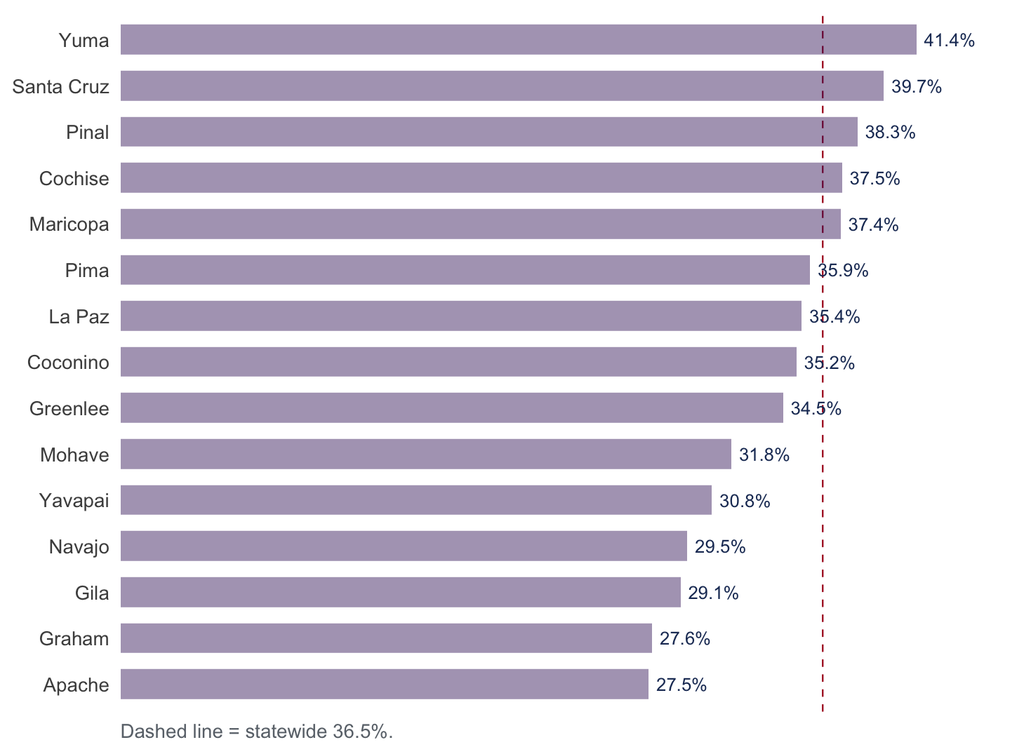